# My outbreak report

Author

Helene Langet

Published

November 27, 2024

## 1 Overview

The outbreak ran from **2021-01-03** to **2022-12-31**. This report covers the period **2021-01-03** to **2021-12-31**. Over the studied period, there were **37024** cases, including **30950** confirmed cases and **884** confirmed deaths.

## 2 Population characteristics

Table 1 provides a summary of the demographic characteristics and the outcome proportion for the overall population, while Table 2 compares the demographic characteristics of individuals who died versus those who are still alive.

Table 1: Population characteristics

| **Characteristic** | **N = 37,024**<sup>1</sup> |
| --- | --- |
| age | 50 (35, 65) |
| sex |  |
| 1 | 18,754 (51%) |
| 2 | 18,270 (49%) |
| bmi | 29 (21, 38) |
| confirmed |  |
| 0 | 6,074 (16%) |
| 1 | 30,950 (84%) |
| death |  |
| 0 | 36,140 (98%) |
| 1 | 884 (2.4%) |

<sup>1</sup> Median (IQR); n (%)

Table 2: Domegraphic characteristics of deceased vs. alive

| **Characteristic** | **Overall**, N = 37,024<sup>1</sup> | **0**, N = 36,140<sup>1</sup> | **1**, N = 884<sup>1</sup> |
| --- | --- | --- | --- |
| sex |  |  |  |
| 1 | 18,754 (51%) | 18,299 (51%) | 455 (51%) |
| 2 | 18,270 (49%) | 17,841 (49%) | 429 (49%) |
| age | 50 (35, 65) | 50 (35, 65) | 52 (38, 67) |
| bmi | 29 (21, 38) | 29 (21, 37) | 35 (29, 42) |

<sup>1</sup> n (%); Median (IQR)

## 3 Outbreak evolution

Figure 1 illustrates the outbreak’s progression, which can be divided into distinct phases.

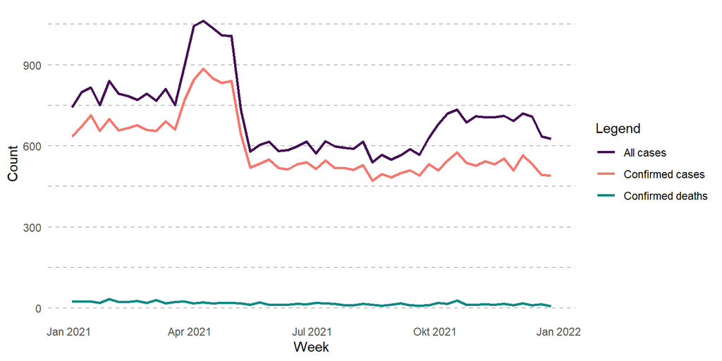

Figure 1: Weekly count of all cases, confirmed cases and deaths

## 4 Logistic regression model

In this section, we build and evaluate a logistic regression model to understand the relationship between certain variables and the likelihood of death among confirmed cases.

The logistic regression model uses `death` as the reponse variable, and `bmi` and `age` as predictor variables. It is implemented in R as shown in the code chunk referenced by Listing 1

Listing 1: R code

```r
coeffs <- glm(death ~ bmi + age,
              subdf |> dplyr::filter(confirmed == "1"),
              family = binomial)
```

The results of the logistic regression model are summarized in the formatted regression table, which is presented in Table 3.

Table 3: Formatted regression table

| **Characteristic** | **OR**<sup>1</sup> | **95% CI**<sup>1</sup> | **p-value** |
| --- | --- | --- | --- |
| bmi | 1.04 | 1.04, 1.05 | <0.001 |
| age | 1.01 | 1.00, 1.01 | 0.002 |

<sup>1</sup> OR = Odds Ratio, CI = Confidence Interval

## 5 Appendix

The dataset includes the following variables:

- `age` = age of the individual (continuous variable) ;
- `sex` = sex of the individual (binary variable: 1 = male, 2 = female) ;
- `bmi` = Body Mass Index (BMI) of the individual (continuous variable) ;
- `confirmed` = flag of confirmed cases (binary variable: 0 = no, 1 = yes)
- `death` = death outcome (binary variable: 0 = alive, 1 = died)

Data summary

| Name | subdf |
| --- | --- |
| Number of rows | 37024 |
| Number of columns | 8 |
| _______________________ |  |
| Column type frequency: |  |
| Date | 2 |
| factor | 3 |
| numeric | 3 |
| ________________________ |  |
| Group variables | None |

**Variable type: Date**

| skim_variable | n_missing | complete_rate | min | max | median | n_unique |
| --- | --- | --- | --- | --- | --- | --- |
| date | 0 | 1 | 2021-01-03 | 2021-12-31 | 2021-06-12 | 363 |
| week | 0 | 1 | 2021-01-03 | 2021-12-26 | 2021-06-06 | 52 |

**Variable type: factor**

| skim_variable | n_missing | complete_rate | ordered | n_unique | top_counts |
| --- | --- | --- | --- | --- | --- |
| sex | 0 | 1 | FALSE | 2 | 1: 18754, 2: 18270 |
| confirmed | 0 | 1 | FALSE | 2 | 1: 30950, 0: 6074 |
| death | 0 | 1 | FALSE | 2 | 0: 36140, 1: 884 |

**Variable type: numeric**

| skim_variable | n_missing | complete_rate | mean | sd | p0 | p25 | p50 | p75 | p100 | hist |
| --- | --- | --- | --- | --- | --- | --- | --- | --- | --- | --- |
| id | 0 | 1 | 5633.56 | 3663.18 | 1 | 2571.00 | 5153.00 | 8434.00 | 14993.00 | ▇▇▆▅▂ |
| age | 0 | 1 | 49.98 | 17.60 | 20 | 35.00 | 50.00 | 65.00 | 80.00 | ▇▇▇▇▇ |
| bmi | 0 | 1 | 30.02 | 11.12 | 10 | 20.99 | 29.14 | 37.59 | 62.22 | ▆▇▇▃▁ |